# IODS course project

Eemeli Annala

# About the project

In this course, *Introduction to Open Data Science*, we will hopefully learn to utilize some methods of open data science. We will use the R programming language to write codes to analyze different types of problems as well as GitHub to store and publish our final products. If you wish to see my GitHub repository, please [click here!](https://github.com/ebetin/IODS-project)

# Regression and model validation

In this exercise, I have earlier created a data set based on the data collected from Johdatus yhteiskuntatilastotieteeseen (autumn 2014) course. [The original study](http://www.helsinki.fi/~kvehkala/JYTmooc/JYTOPKYS3-meta.txt) examined study success, motivation and learning habits of social science students.

## Explaining the data set

Let us start by reading the data file and studying its properties:

```r
lrn14 <- read.table("data/learning2014.txt", sep="\t", header=TRUE)
```

We can study the dimension of the data by writing:

```r
dim(lrn14)
```

```
## [1] 166   7
```

It seems that the data set contains 7 columns and 166 rows.

And to study the structure:

```r
str(lrn14)
```

```
## 'data.frame':    166 obs. of  7 variables:
##  $ gender  : Factor w/ 2 levels "F","M": 1 2 1 2 2 1 2 1 2 1 ...
##  $ age     : int  53 55 49 53 49 38 50 37 37 42 ...
##  $ attitude: num  3.7 3.1 2.5 3.5 3.7 3.8 3.5 2.9 3.8 2.1 ...
##  $ deep    : num  3.58 2.92 3.5 3.5 3.67 ...
##  $ stra    : num  3.38 2.75 3.62 3.12 3.62 ...
##  $ surf    : num  2.58 3.17 2.25 2.25 2.83 ...
##  $ points  : int  25 12 24 10 22 21 21 31 24 26 ...
```

The first two columns introduce some basic information about the students, ie. genders and ages, respectively. The third one is an average of ten questions on Likert scale describing students’ attitude toward statistics, and the following three columns measure subjects’ deep, strategical and surface learning, respectively. Finally, the last one contains the exam points.

## Basic statistical properties

To further study the data set, we can use summary() command to calculate some basic statistical properties, such as mean or median:

```r
summary(lrn14)
```

```
##  gender       age           attitude          deep            stra
##  F:110   Min.   :17.00   Min.   :1.400   Min.   :1.583   Min.   :1.250
##  M: 56   1st Qu.:21.00   1st Qu.:2.600   1st Qu.:3.333   1st Qu.:2.625
##          Median :22.00   Median :3.200   Median :3.667   Median :3.188
##          Mean   :25.51   Mean   :3.143   Mean   :3.680   Mean   :3.121
##          3rd Qu.:27.00   3rd Qu.:3.700   3rd Qu.:4.083   3rd Qu.:3.625
##          Max.   :55.00   Max.   :5.000   Max.   :4.917   Max.   :5.000
##       surf           points
##  Min.   :1.583   Min.   : 7.00
##  1st Qu.:2.417   1st Qu.:19.00
##  Median :2.833   Median :23.00
##  Mean   :2.787   Mean   :22.72
##  3rd Qu.:3.167   3rd Qu.:27.75
##  Max.   :4.333   Max.   :33.00
```

On the other hand, we can also make pair plots between to describe relations between given variables. Note that here the blue color represents males and the red one females.

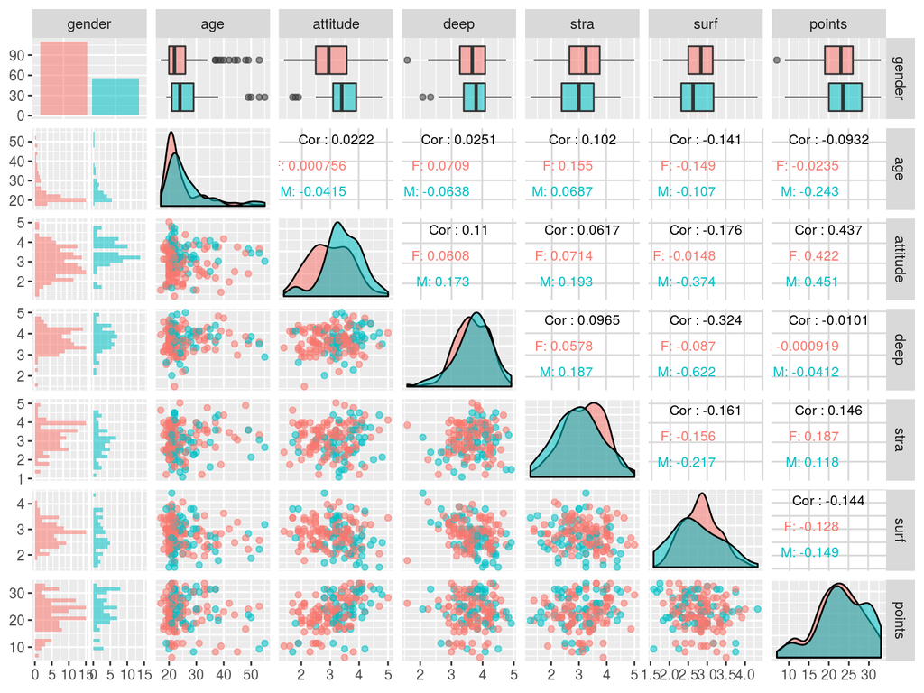

```r
# pair plots
ggpairs(lrn14, mapping = aes(alpha = 0.3, col = gender), upper = list(continuous = wrap("cor", size = 3)), lower = list(combo = wrap("facethist", bins = 20)))
```

What is surprising is that most of the distributions are, from certain extent, bell-shaped, or at least, mainly unimodal. Furthermore, there exist quite strong positive correlation between exam score and student’s attitude toward statistics which is not unexpected. However, there also exists a mild negative correlation between surface and deep learning which is, at first glance, weird.

## Multiple regression

Let us then study how the exam score depends on the other variables. Based on the previous figure the most promising candidates for explanatory variables are attitude (cov = 0.437) as well as strategical (0.146) and surface learning (-0.144). By using linear, multiple regression, we find out that:

```r
# linear regression model
regression_model3 = lm(points ~ attitude + stra + surf, data = lrn14)

# summary of our model
summary(regression_model3)
```

```
##
## Call:
## lm(formula = points ~ attitude + stra + surf, data = lrn14)
##
## Residuals:
##      Min       1Q   Median       3Q      Max
## -17.1550  -3.4346   0.5156   3.6401  10.8952
##
## Coefficients:
##             Estimate Std. Error t value Pr(>|t|)
## (Intercept)  11.0171     3.6837   2.991  0.00322 **
## attitude      3.3952     0.5741   5.913 1.93e-08 ***
## stra          0.8531     0.5416   1.575  0.11716
## surf         -0.5861     0.8014  -0.731  0.46563
## ---
## Signif. codes:  0 '***' 0.001 '**' 0.01 '*' 0.05 '.' 0.1 ' ' 1
##
## Residual standard error: 5.296 on 162 degrees of freedom
## Multiple R-squared:  0.2074, Adjusted R-squared:  0.1927
## F-statistic: 14.13 on 3 and 162 DF,  p-value: 3.156e-08
```

Therefore, based on the summary, the only explanatory variable which is statistically significant, ie. the p-value is smaller than the significant level $\alpha$, is the attitude, when $\alpha = 0.05$. Therefore, we may discard other two variables and do the analyze again:

```r
regression_model2 = lm(points ~ attitude, data = lrn14)
summary(regression_model2)
```

```
##
## Call:
## lm(formula = points ~ attitude, data = lrn14)
##
## Residuals:
##      Min       1Q   Median       3Q      Max
## -16.9763  -3.2119   0.4339   4.1534  10.6645
##
## Coefficients:
##             Estimate Std. Error t value Pr(>|t|)
## (Intercept)  11.6372     1.8303   6.358 1.95e-09 ***
## attitude      3.5255     0.5674   6.214 4.12e-09 ***
## ---
## Signif. codes:  0 '***' 0.001 '**' 0.01 '*' 0.05 '.' 0.1 ' ' 1
##
## Residual standard error: 5.32 on 164 degrees of freedom
## Multiple R-squared:  0.1906, Adjusted R-squared:  0.1856
## F-statistic: 38.61 on 1 and 164 DF,  p-value: 4.119e-09
```

Using the given summary, one is able to see that the slope coefficient is positive. This indicates that there is a positive correlation between person’s exam score and their attitude towards statistics, ie. motivated students get better grades. On the other hand, this result also revels that the exam score depends on strategical and surface learning parameters only weakly.

## Multiple R-square

The multiple R-square tells us how well the fitted linear function describes the given data, and its value is always between zero and one. So in general case, higher the R-square better is the model.

The multiple R-squared values of the presented models are quite small (0.21 and 0.19, respectively) but not close to zero. As stated above, small value typically indicates that the model does not explain the behavior of the target variable. However, the result is not unpredictable because the population consist of humans, and humans do not statistically behave as well as elementary particle, for example. Furthermore in our latter model, the statistical significants of model constants are huge, and hence, we can state that fit is faithful according to this diagnostic.

## Diagnostic plots

The assumptions of the linear regression model are follow: * Linear regression really exist * Errors are normally distributed with constant variance * Errors are not correlated * Errors do not depend on model variables.

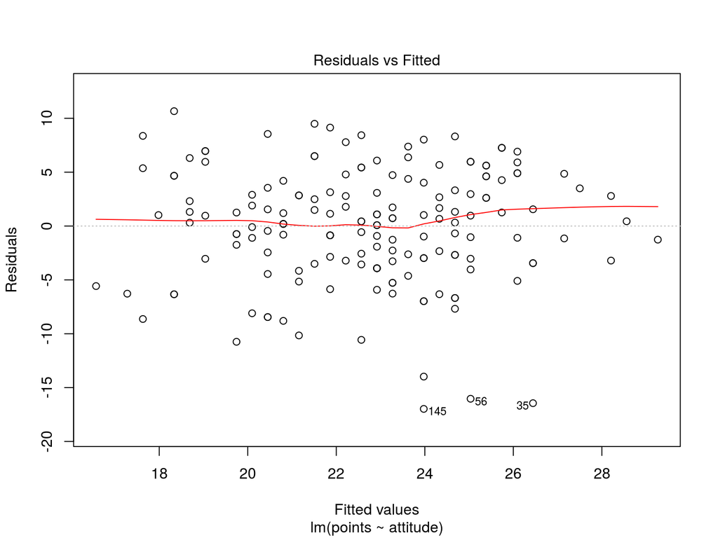

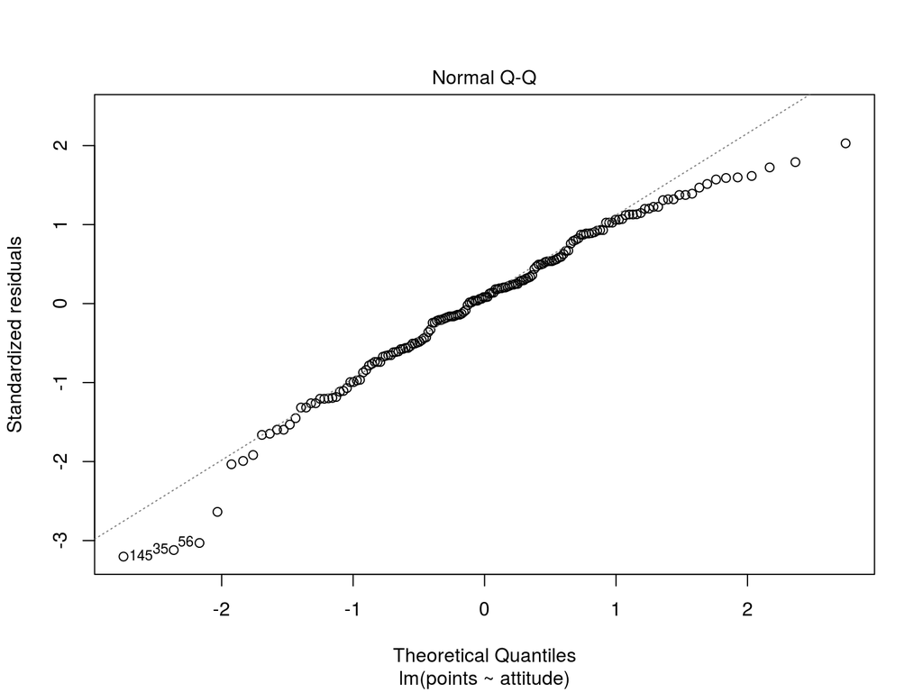

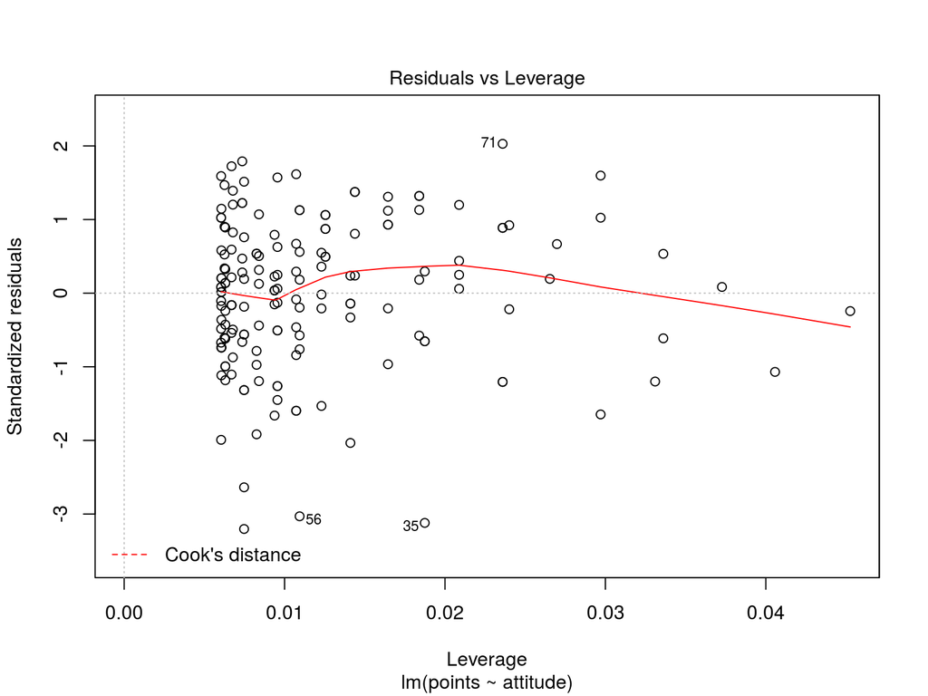

```r
#Plotting residuals vs. fitted values (1), normal QQ-plot (2) and residuals vs leverage (5)
plot(regression_model2, which = c(1,2,5))
```

In the residual vs. fitted data plot, everything seems to be mostly just fine, and distinguishable separation from the ground level does not appear. Nonetheless, three data points stand out (#35, #56 and #145). Even so, this diagnostic plot indicates that the situation is truly linear.

Correspondingly, the normal QQ-plot continues the story, but now there exists some deviation from the baseline at both ends. Nonetheless, the underlying distribution can be still seen reasonable normal. Finally, the residuals vs. Leverage plot can be used to study the last assumption, and because we do not see any extreme outliers, we can state that the assumption holds.

Based on the diagnostic plots, one may state that the assumptions of the given model are valid.

# Logistic regression

This week we are studying logistic regression.

## Explaining the data set

During this exercise, we are studying a data set which contains information about students’ grades and factors affecting on them. If you want to have some more information about the set, see the [original study](https://archive.ics.uci.edu/ml/datasets/Student+Performance).

Let us start by reading the data file ‘alc.txt’ and studying its properties:

```r
alc <- read.table("data/alc.txt", sep="\t", header=TRUE)
```

Let us then see which kind of variables the file contains

```r
colnames(alc)
```

```
##  [1] "school"     "sex"        "age"        "address"    "famsize"
##  [6] "Pstatus"    "Medu"       "Fedu"       "Mjob"       "Fjob"
## [11] "reason"     "nursery"    "internet"   "guardian"   "traveltime"
## [16] "studytime"  "failures"   "schoolsup"  "famsup"     "paid"
## [21] "activities" "higher"     "romantic"   "famrel"     "freetime"
## [26] "goout"      "Dalc"       "Walc"       "health"     "absences"
## [31] "G1"         "G2"         "G3"         "alc_use"    "high_use"
```

You may see 35 different variables, such as ‘age’ or ‘sex’. But in this exercise we are interested in to study alcohol consumption, and therefore, ‘alc_use’ and ‘high_use’ are the relevant variables. Here, ‘alc_use’ is the average of weekday (Dalc) and weekend (Walc) comsumption on Likert scale. Besides, the ‘high_use’ variable tells use when the alcohol consumption is high, ie. ‘alc_use’ > 2.

Note that the used data set is an intersection of two data set provided by the original study. Hence, all numerical variables are average values.

## Alcohol consumption

I have four hypothesis related to high alcohol consumption:  
1. People whose final scores (‘G3’) are low, are liker to use a lot of alcohol.  
2. The alcohol consumption of young (‘age’) people is high.  
3. Good relationships (‘famrel’) with your family members prevent drinking.  
4. People who use lots of alcohol fail courses (‘failures’) more often.

### Hypothesis 1

In this section, we will study the first hypothesis “people whose final scores (‘G3’) are low, are likier to use a lot of alcohol.” Lets us first make a box plot

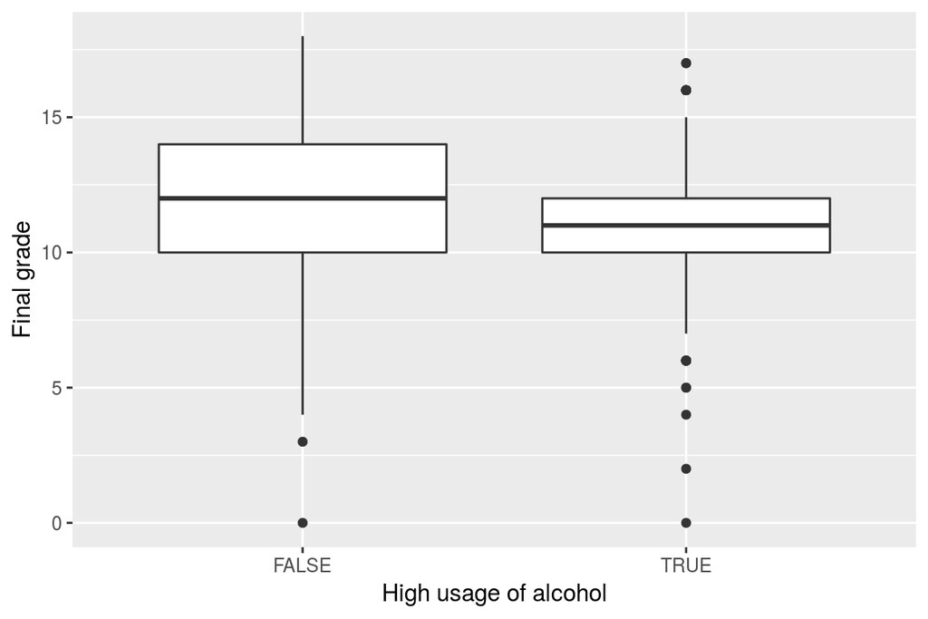

```r
g1 <- ggplot(alc, aes(x = high_use, y = G3))
g1 + geom_boxplot() + ylab("Final grade") + xlab("High usage of alcohol")
```

and a bar one:

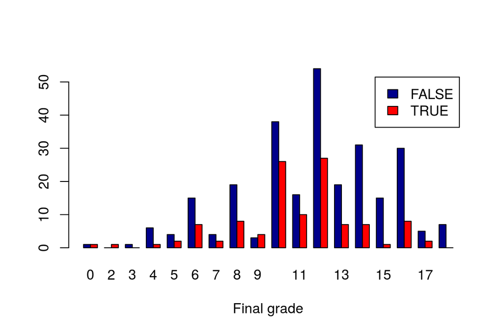

```r
counts <- table(alc$high_use, alc$G3)
barplot(counts, col=c("darkblue","red"), beside=T, legend = rownames(counts), xlab = "Final grade")
```

Based on these plots, it seems that the mean final score is indeed higher within students who do not use a lot of alcohol. Nevertheless in that case, the variance is also notable higher which is a bit suprising. But based on these findings we can state that most probably there is not any tendency towards the hypothesis.

### Hypothesis 2

Let us then study the hypothesis number 2: “The alcohol consumption of young (‘age’) people is high” by making a box and a bar plots:

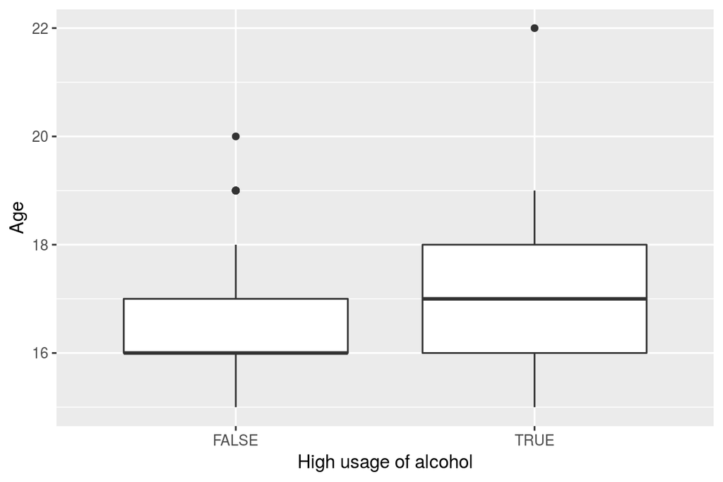

```r
g1 <- ggplot(alc, aes(x = high_use, y = age))
g1 + geom_boxplot() + ylab("Age") + xlab("High usage of alcohol")
```

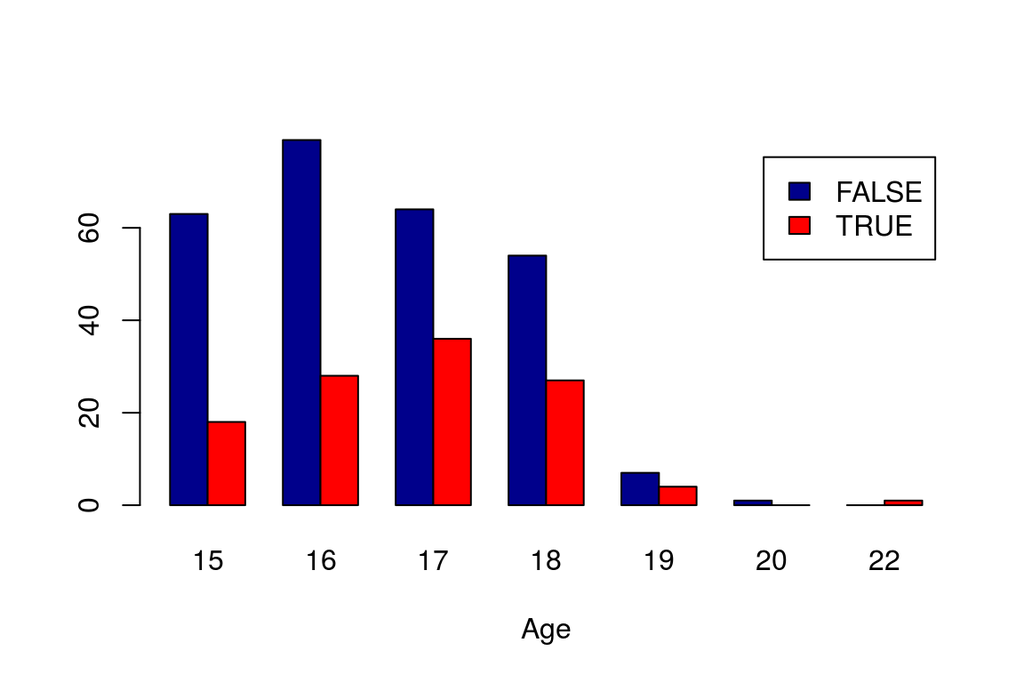

```r
counts <- table(alc$high_use, alc$age)
barplot(counts, col=c("darkblue","red"), beside=T, legend = rownames(counts), xlab = "Age")
```

### Hypothesis 3

The third hypothesis states “Good relationships (‘famrel’) with your family members prevent drinking.”

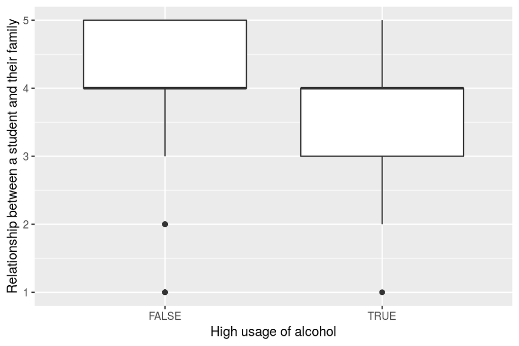

```r
g1 <- ggplot(alc, aes(x = high_use, y = famrel))
g1 + geom_boxplot() + ylab("Relationship between a student and their family") + xlab("High usage of alcohol")
```

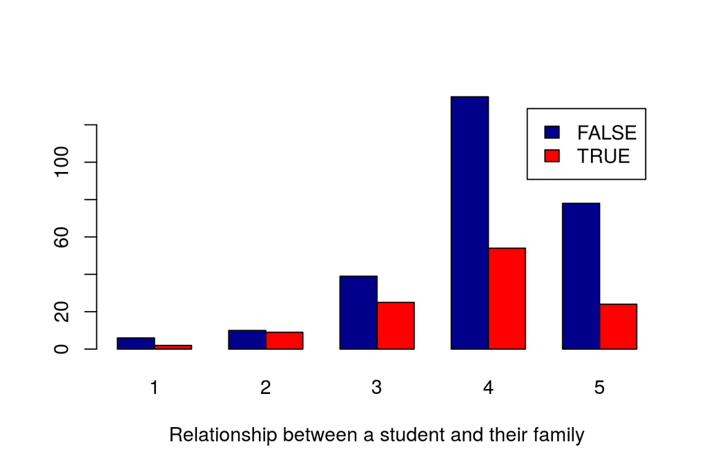

```r
counts <- table(alc$high_use, alc$famrel)
barplot(counts, col=c("darkblue","red"), beside=T, legend = rownames(counts), xlab = "Relationship between a student and their family")
```

Based on the plots it seems like the statement is some what true. Even to the average (4) relationship in Likert scale is the same on both cases, the distribution is, in the case of low alcohol consumption, tilted toward the highest value. Conversely in the other case, the distribution is around the average value.

### Hypothesis 4

The last hypothesis is given as: “People who use lots of alcohol fail coerces (‘failures’) more often.”

```r
xtabs(~ failures + high_use, data = alc)
```

```
##         high_use
## failures FALSE TRUE
##        0   244   90
##        1    12   12
##        2    10    9
##        3     2    3
```

## Logistic regression

Let us fit a logistic regression model which uses our chosen variables from the previous section to explain the high/low usage of alcohol, and then let us see the model summary

```r
logistic_model <- glm(high_use ~ G3 + age + famrel + failures, data = alc, family = "binomial")
summary(logistic_model)
```

```
##
## Call:
## glm(formula = high_use ~ G3 + age + famrel + failures, family = "binomial",
##     data = alc)
##
## Deviance Residuals:
##    Min      1Q  Median      3Q     Max
## -1.542  -0.829  -0.706   1.347   1.873
##
## Coefficients:
##             Estimate Std. Error z value Pr(>|z|)
## (Intercept) -2.14681    1.80022  -1.193   0.2331
## G3          -0.04474    0.03728  -1.200   0.2301
## age          0.16300    0.10009   1.629   0.1034
## famrel      -0.25594    0.12403  -2.064   0.0391 *
## failures     0.36424    0.19818   1.838   0.0661 .
## ---
## Signif. codes:  0 '***' 0.001 '**' 0.01 '*' 0.05 '.' 0.1 ' ' 1
##
## (Dispersion parameter for binomial family taken to be 1)
##
##     Null deviance: 465.68  on 381  degrees of freedom
## Residual deviance: 448.27  on 377  degrees of freedom
## AIC: 458.27
##
## Number of Fisher Scoring iterations: 4
```

Based on the summary, we can see that the family relationship (‘famrel’) is the only variable which p-value is under the 0.05 significant level. Hence, we can state the the findings of the previous are line with this analyze, or in other words, the only statistically obvious relationship is between high/low alcohol usage and the family relationship.

Let us present the model coeffiecients and calculate their confidence intervals:

```r
odd_ratio <- coef(logistic_model) %>% exp
conf_intervals <- confint(logistic_model) %>% exp
cbind(odd_ratio, conf_intervals)
```

```
##             odd_ratio       2.5 %   97.5 %
## (Intercept) 0.1168569 0.003334282 3.945043
## G3          0.9562495 0.888423175 1.028613
## age         1.1770412 0.968307038 1.434907
## famrel      0.7741855 0.606291127 0.987785
## failures    1.4394173 0.975965957 2.136111
```

The odd ration of the variables ‘G3’ and ‘famrel’ seem to be (about) below one and the other two (about) above on. However, the variable ‘famrel’ is the only one which clearly below one, ie. it support that there is a negative association with the high/low drinking factor. This finding also support our hypothesis number 3.

On the other hand, the variable ‘failures’ is the only (quite) quantity clearly above one. This result indicates that the number of failed classes is higher is the person is drinking a lot. The p-value of the variables is quite close to the significant level but just above it (0.066). This piece of information also points to the direction that the there is a connection but not a very visible one.

## Prediction power

Based on the analyses given in the previous section, the only variable which gives statistically significant relationship with the high/low consumption of alcohol is ‘famrel’. Nonetheless, we are also including the almost statistically significant parameter ‘failures’ (because this would be boring without).

So let us first define the new logistic regression model

```r
logistic_model_updated <- glm(high_use ~ famrel + failures, data = alc, family = "binomial")
summary(logistic_model_updated)
```

```
##
## Call:
## glm(formula = high_use ~ famrel + failures, family = "binomial",
##     data = alc)
##
## Deviance Residuals:
##     Min       1Q   Median       3Q      Max
## -1.4132  -0.7926  -0.7926   1.3890   1.7302
##
## Coefficients:
##              Estimate Std. Error z value Pr(>|z|)
## (Intercept) -0.009978   0.490131  -0.020  0.98376
## famrel      -0.246686   0.122493  -2.014  0.04402 *
## failures     0.511941   0.180980   2.829  0.00467 **
## ---
## Signif. codes:  0 '***' 0.001 '**' 0.01 '*' 0.05 '.' 0.1 ' ' 1
##
## (Dispersion parameter for binomial family taken to be 1)
##
##     Null deviance: 465.68  on 381  degrees of freedom
## Residual deviance: 452.95  on 379  degrees of freedom
## AIC: 458.95
##
## Number of Fisher Scoring iterations: 4
```

Now, it seems that the variable ‘failures’ fits well which was not the case in previous section.

Then let us then make a 2x2 cross tabulation of predictions versus the actual values:

```r
# predict() the probability of high_use
probabilities <- predict(logistic_model_updated, type = "response")

# add the predicted probabilities to 'alc'
alc <- mutate(alc, probability = probabilities)

# use the probabilities to make a prediction of high_use
alc <- mutate(alc, prediction = probability > 0.5)

# tabulate the target variable versus the predictions
table(high_use = alc$high_use, prediction = alc$prediction)
```

```
##         prediction
## high_use FALSE TRUE
##    FALSE   254   14
##    TRUE    104   10
```

As you can see the model works pretty well, ie. in 264 cases the model gives the right results. Nonetheless, there is 14 cases when false positive and 104 cases when false negative results occurs. All in all, we cannot say that this model is perfect.

Besides, we may also make a plot to visualize this results:

```r
# Some plotting libraries
library(dplyr)
library(ggplot2)
```

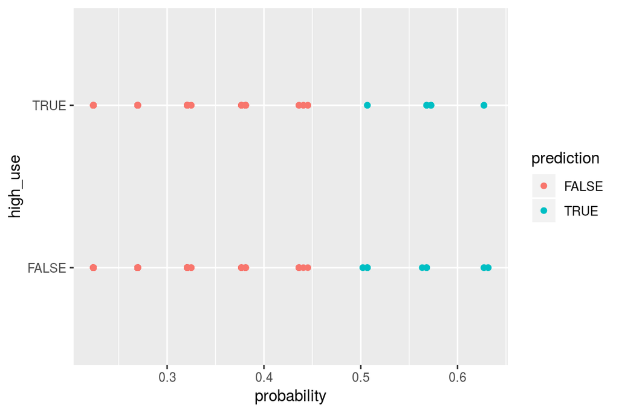

```r
# initialize a plot of 'high_use' versus 'probability' in 'alc'
g <- ggplot(alc, aes(x = probability, y = high_use, col = prediction))

# define the geom as points and draw the plot
g + geom_point()
```

Finally, let us calculate the training error:

```r
# define a loss function (mean prediction error)
loss_func <- function(class, prob) {
  n_wrong <- abs(class - prob) > 0.5
  mean(n_wrong)
}

# call loss_func to compute the average number of wrong predictions in the (training) data
loss_func(class = alc$high_use, prob = alc$probability)
```

```
## [1] 0.3089005
```

This results indicates that error is about 0.31. The error is somewhat large but it is reasonable because the p-value of variable ‘famrel’ is close to the significant level, 0.05. Furthermore, we have to also remember that the data set is describing some subset of human population and therefore, the error is excepted to be a bit higher.

# Clustering and classification

Hopefully, I am going to learn something about clustering and classification theory.

## Data set

In this exercise, we will study the so called Boston data set. This set contains information about “housing values in suburbs of Boston” (see [the meta file](https://stat.ethz.ch/R-manual/R-devel/library/MASS/html/Boston.html)).

Let us first read the Boston data from the MASS package:

```r
# let us load the object 'Boston'
data(Boston)
```

Then we might study it dimensions:

```r
dim(Boston)
```

```
## [1] 506  14
```

and its structure:

```r
str(Boston)
```

```
## 'data.frame':    506 obs. of  14 variables:
##  $ crim   : num  0.00632 0.02731 0.02729 0.03237 0.06905 ...
##  $ zn     : num  18 0 0 0 0 0 12.5 12.5 12.5 12.5 ...
##  $ indus  : num  2.31 7.07 7.07 2.18 2.18 2.18 7.87 7.87 7.87 7.87 ...
##  $ chas   : int  0 0 0 0 0 0 0 0 0 0 ...
##  $ nox    : num  0.538 0.469 0.469 0.458 0.458 0.458 0.524 0.524 0.524 0.524 ...
##  $ rm     : num  6.58 6.42 7.18 7 7.15 ...
##  $ age    : num  65.2 78.9 61.1 45.8 54.2 58.7 66.6 96.1 100 85.9 ...
##  $ dis    : num  4.09 4.97 4.97 6.06 6.06 ...
##  $ rad    : int  1 2 2 3 3 3 5 5 5 5 ...
##  $ tax    : num  296 242 242 222 222 222 311 311 311 311 ...
##  $ ptratio: num  15.3 17.8 17.8 18.7 18.7 18.7 15.2 15.2 15.2 15.2 ...
##  $ black  : num  397 397 393 395 397 ...
##  $ lstat  : num  4.98 9.14 4.03 2.94 5.33 ...
##  $ medv   : num  24 21.6 34.7 33.4 36.2 28.7 22.9 27.1 16.5 18.9 ...
```

It seems that the data set contains 506 observations (rows) and 14 variables (columns). The definition of variables can be found from the meta file.

## Overview

Let us then study the summary of the given data set:

```r
summary(Boston)
```

```
##       crim                zn             indus            chas
##  Min.   : 0.00632   Min.   :  0.00   Min.   : 0.46   Min.   :0.00000
##  1st Qu.: 0.08204   1st Qu.:  0.00   1st Qu.: 5.19   1st Qu.:0.00000
##  Median : 0.25651   Median :  0.00   Median : 9.69   Median :0.00000
##  Mean   : 3.61352   Mean   : 11.36   Mean   :11.14   Mean   :0.06917
##  3rd Qu.: 3.67708   3rd Qu.: 12.50   3rd Qu.:18.10   3rd Qu.:0.00000
##  Max.   :88.97620   Max.   :100.00   Max.   :27.74   Max.   :1.00000
##       nox               rm             age              dis
##  Min.   :0.3850   Min.   :3.561   Min.   :  2.90   Min.   : 1.130
##  1st Qu.:0.4490   1st Qu.:5.886   1st Qu.: 45.02   1st Qu.: 2.100
##  Median :0.5380   Median :6.208   Median : 77.50   Median : 3.207
##  Mean   :0.5547   Mean   :6.285   Mean   : 68.57   Mean   : 3.795
##  3rd Qu.:0.6240   3rd Qu.:6.623   3rd Qu.: 94.08   3rd Qu.: 5.188
##  Max.   :0.8710   Max.   :8.780   Max.   :100.00   Max.   :12.127
##       rad              tax           ptratio          black
##  Min.   : 1.000   Min.   :187.0   Min.   :12.60   Min.   :  0.32
##  1st Qu.: 4.000   1st Qu.:279.0   1st Qu.:17.40   1st Qu.:375.38
##  Median : 5.000   Median :330.0   Median :19.05   Median :391.44
##  Mean   : 9.549   Mean   :408.2   Mean   :18.46   Mean   :356.67
##  3rd Qu.:24.000   3rd Qu.:666.0   3rd Qu.:20.20   3rd Qu.:396.23
##  Max.   :24.000   Max.   :711.0   Max.   :22.00   Max.   :396.90
##      lstat            medv
##  Min.   : 1.73   Min.   : 5.00
##  1st Qu.: 6.95   1st Qu.:17.02
##  Median :11.36   Median :21.20
##  Mean   :12.65   Mean   :22.53
##  3rd Qu.:16.95   3rd Qu.:25.00
##  Max.   :37.97   Max.   :50.00
```

and make a graphical interpretation of the distribution:

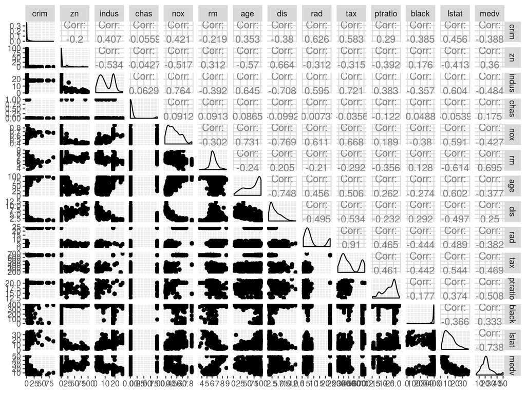

```r
ggpairs(Boston)
```

and present the correlation plot as well:

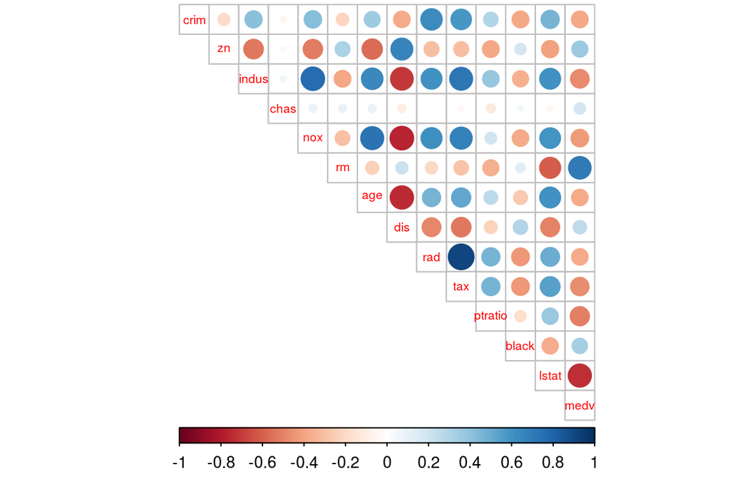

```r
# correlation matrix with rounding
cor_matrix<-cor(Boston) %>% round(digits = 2)

# correlation plot, upper triangle
corrplot(cor_matrix, method="circle", type="upper", cl.pos = "b", tl.pos = "d", tl.cex = 0.6)
```

If we study the distibutions, we may see that many of them are bimodular ad the modes are far apart, such as ‘indus’, ‘tax’ and ‘rad’. On the other hand, one can also find distibution which are heavily skewed, e.g. ‘black’, ‘crim’ and ‘zn’. Correlation wise, the situaton is interesting because various strong correlation can be detected, and interestingly, only a few situation suggest a small (absolute value of) correlation. (NB One should note that the variable ‘chas’ is a dummy variable and should be ignored.)